# M3-Regresi Peubah Lag

Rafli Radithya

17/9/2023

# TUGAS PRAKTIKUM 3 REGRESI DENGAN PEUBAH LAG

## Tentang Data

Data yang digunakan merupakan data m4 competition forecasting yang diperoleh dari website Kaggle ([<https://www.kaggle.com/datasets/yogesh94/m4-forecasting-competition-dataset>](https://www.kaggle.com/datasets/yogesh94/m4-forecasting-competition-dataset)) dengan banyak datanya 1000 baris. Adapun daftar peubahnya terdiri dari

1. V2 = y (peubah respon)
2. V5 = x (peubah bebas)

Dalam tugas ini, digunakan 2 peubah tersebut dengan V2 sebagai peubah dependen dan V5 sebagai peubah independen

## Eksplorasi Data

1. Persiapan Package

   ```r
   library(dLagM)
   library(dynlm)
   library(MLmetrics)
   library(lmtest)
   library(car)
   ```

2. Input data

   ```r
   #Akses data
   setwd("C:/Users/USER/OneDrive/Dokumen/PRAKTIKUM MPDW 2023/PRAKTIKUM MPDW 2023/pertemuan2/data")
   mpdw=read.csv("mpdw2v2.csv",sep=";")
   mpdw3=as.data.frame(mpdw)

   #Diambil 1000 data
   mpdw3=mpdw3[1:1000,]
   mpdw3
   ```

   ```
   ##             V2        V3        V4        V5
   ## 1     2039.200  2035.000  2051.800  2061.800
   ## 2     2986.000  3001.200  2975.900  2996.100
   ## 3     1120.700  1117.900  1115.100  1112.300
   ## 4     1190.000  1162.000  1134.000  1106.000
   ## 5     5904.670  5917.050  5922.580  5928.800
   ## 6     3182.052  3147.099  3143.850  3128.200
   ## 7     5860.008  7773.246  9477.872  8209.099
   ## 8     1732.200  1731.830  1739.170  1741.800
   ## 9     1584.410  1584.060  1590.770  1592.650
   ## 10    2618.000  2638.600  2648.700  2656.200
   ## 11    2440.200  2439.700  2469.300  2434.400
   ## 12    3663.300  3670.600  3704.100  3695.200
   ## 13    7208.400  7262.700  7251.200  7320.400
   ## 14    5762.900  5721.800  5789.500  5756.000
   ```

   [output cut: 986 more lines]

3. Plot time series untuk setiap peubah

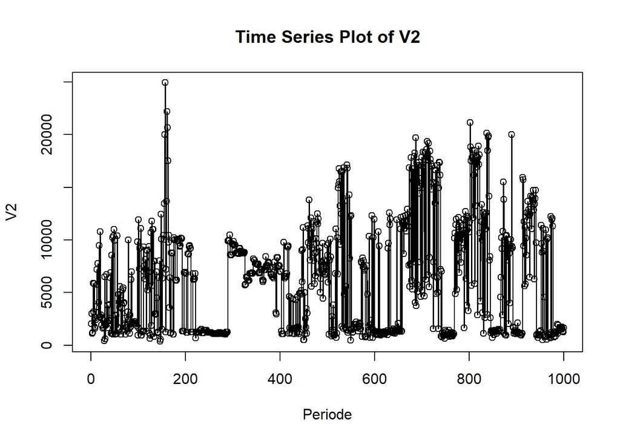

   ```r
   par(mfrow = c(1,1))
   #V2
   v2.ts=ts(mpdw3$V2)
   ts.plot(v2.ts, xlab="Periode", ylab="V2", main= "Time Series Plot of V2")
   points(v2.ts)
   ```

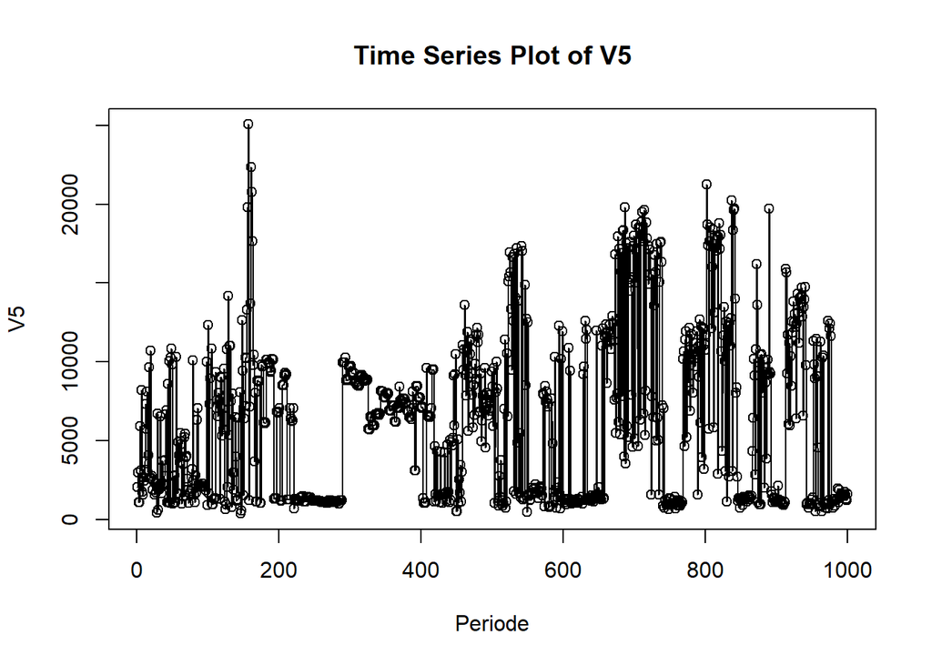

   ```r
   #V5
   v5.ts=ts(mpdw3$V5)
   ts.plot(v5.ts, xlab="Periode", ylab="V5", main= "Time Series Plot of V5")
   points(v5.ts)
   ```

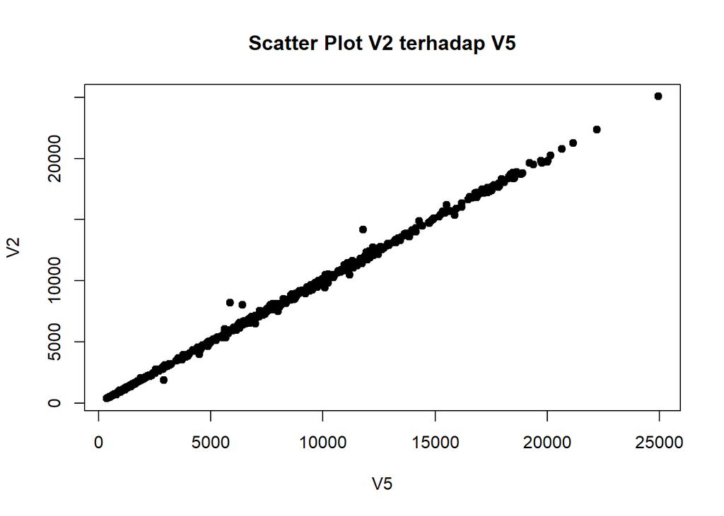

   ```r
   plot(mpdw3$V2,mpdw3$V5,xlab ="V5",ylab = "V2",main="Scatter Plot V2 terhadap V5",pch=19)
   ```

   ```r
   cor(mpdw3$V2,mpdw3$V5)
   ```

   ```
   ## [1] 0.9994559
   ```

## Regresi Lag dengan Model Kyock

1. Pembagian data training & testing

   Dari 1000 data, akan dibagi menjadi 80% data training dan 20% data testing untuk membangun dan mengevaluasi model kyock

   ```r
   #Pembagian data
   train=mpdw3[1:800,] #Data training sebanyak 800 data
   test=mpdw3[801:1000,] #Data testing sebanyak 200 data

   #Penggantian menjadi data time series
   #data time series
   train.ts<-ts(train)
   test.ts<-ts(test)
   mpdw3.ts<-ts(mpdw3)
   ```

2. Plot data training dan testing

   Untuk mencegah terjadinya overfitting data, dilakukan pencocokan data training vs testing

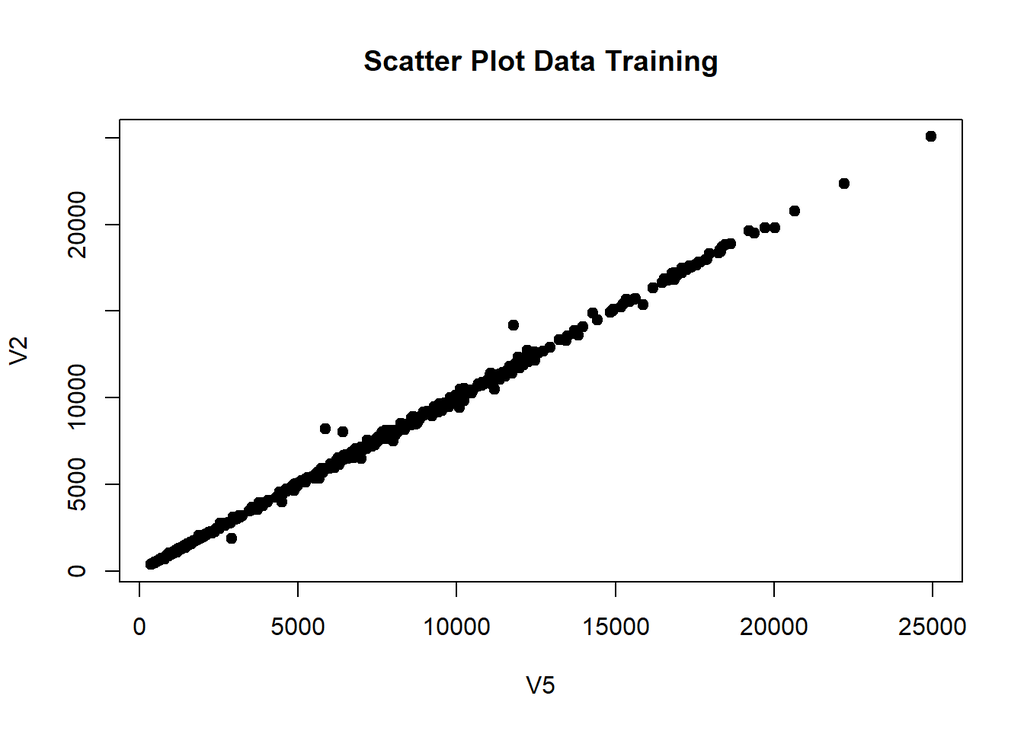

   ```r
   par(mfrow = c(1,1))
   plot(train$V2,train$V5,xlab ="V5",ylab = "V2",main="Scatter Plot Data Training",pch=19)
   ```

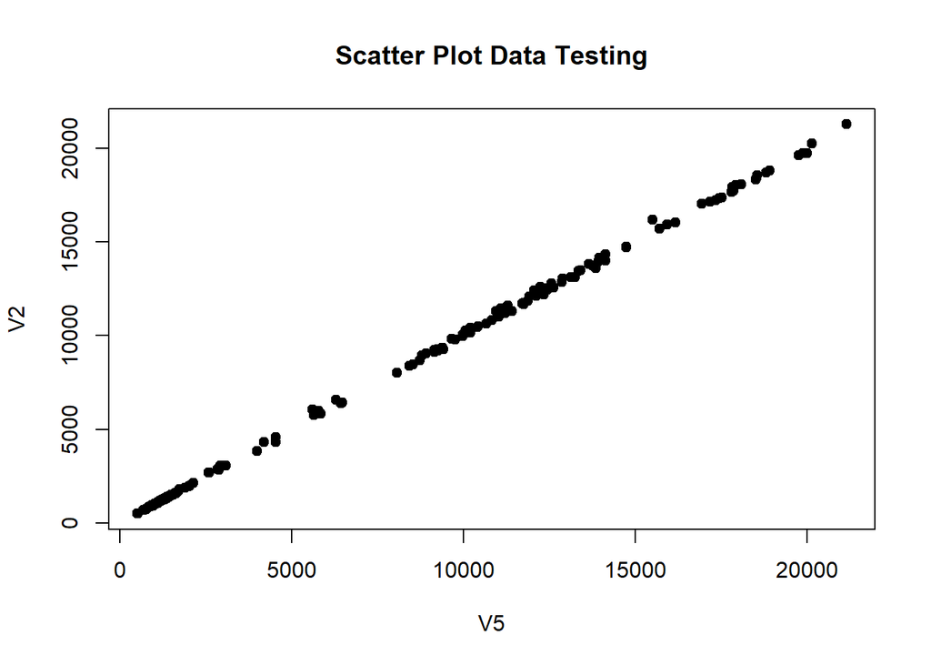

   ```r
   plot(test$V2,test$V5,xlab ="V5",ylab = "V2",main="Scatter Plot Data Testing",pch=19)
   ```

   Berdasarkan scatter plot data training dan testing, kedua plot menunjukan pola tren yang sama sehingga data testing cukup baik untuk dapat digunakan mengevaluasi model nantinya
3. Pembuatan model regresi lag Kyock

   ```r
   #MODEL KOYCK
   model.koyck <- koyckDlm(x=train$V2, y=train$V5)
   summary(model.koyck)
   ```

   ```
   ##
   ## Call:
   ## "Y ~ (Intercept) + Y.1 + X.t"
   ##
   ## Residuals:
   ##      Min       1Q   Median       3Q      Max
   ## -1102.32  -151.67   -94.73   131.02  2837.75
   ##
   ## Coefficients:
   ##              Estimate Std. Error t value Pr(>|t|)
   ## (Intercept) 174.98857   79.11075   2.212   0.0273 *
   ## Y.1           0.03131    0.01558   2.009   0.0448 *
   ## X.t           0.94255    0.02825  33.368   <2e-16 ***
   ## ---
   ## Signif. codes:  0 '***' 0.001 '**' 0.01 '*' 0.05 '.' 0.1 ' ' 1
   ##
   ## Residual standard error: 321.5 on 796 degrees of freedom
   ## Multiple R-Squared: 0.9956,  Adjusted R-squared: 0.9956
   ## Wald test: 2.749e+04 on 2 and 796 DF,  p-value: < 2.2e-16
   ##
   ## Diagnostic tests:
   ## NULL
   ##
   ##                             alpha     beta        phi
   ## Geometric coefficients:  180.6444 0.942554 0.03130926
   ```

   ```r
   aic.kyock=AIC(model.koyck)
   ```

   ```
   ## [1] 11497.78
   ```

   ```r
   bic.kyock=BIC(model.koyck)
   ```

   ```
   ## [1] 11516.51
   ```

   Dari hasil di atas, diperoleh bahwa peubah $x_t$ dan $y_{t-1}$ memiliki nilai $P-value < 0.05$ yang berarti signifikan pada taraf 5%. Selain itu, didapatkan nilai $R-square$ sebesar 0.9956. Adapun nilai AIC yang didapatkan sebesar 11497.78 dan BIC sebesar 11516.51
4. Forecasting & akurasi model Kyock

   Model yang didapat dari data training digunakan untuk forecast data testing yang sebanyak 200 periode ke depan. Selanjutnya, dari hasil forecasting, dilakukan evaluasi kebaikan model berdasarkan respon dari data testing dengan MAPE

   ```r
   #Forecasting MODEL KOYCK
   fore.koyck <- forecast(model = model.koyck, x=test$V5, h=200)

   #MAPE data testing
   mape.koyck <- MAPE(fore.koyck$forecasts, test$V2)

   #akurasi data training
   MAPE_training=GoF(model.koyck)

   #Hasil evaluasi
   hasil1=data.frame(MAPE_training$MAPE,mape.koyck)
   colnames(hasil1)<-c("MAPE Training","MAPE Testing")
   hasil1
   ```

   ```
   ##   MAPE Training MAPE Testing
   ## 1    0.08115668   0.09595966
   ```

   Nilai MAPE data training adalah 0.08115668 sementara nilai MAPE data testing adalah 0.09595966 sehingga keduanya menunjukan nilai MAPE <10%. Oleh karena itu, model yang didapatkan cukup baik dan tidak overfitting.

## Regresi Lag dengan Distributed Lag

1. Pemodelan dengan pemilihan lag = 2

   ```r
   #Pemodelan lag dengan q = 2
   model.dlm <- dlm(x = train$V5,y = train$V2 , q = 2)
   summary(model.dlm)
   ```

   ```
   ##
   ## Call:
   ## lm(formula = model.formula, data = design)
   ##
   ## Residuals:
   ##      Min       1Q   Median       3Q      Max
   ## -2290.83   -42.47    -6.82    43.94   999.96
   ##
   ## Coefficients:
   ##              Estimate Std. Error t value Pr(>|t|)
   ## (Intercept) 13.592857  11.391724   1.193 0.233139
   ## x.t          0.990063   0.001643 602.506  < 2e-16 ***
   ## x.1          0.006373   0.001676   3.803 0.000154 ***
   ## x.2         -0.001723   0.001644  -1.048 0.294864
   ## ---
   ## Signif. codes:  0 '***' 0.001 '**' 0.01 '*' 0.05 '.' 0.1 ' ' 1
   ##
   ## Residual standard error: 178.9 on 794 degrees of freedom
   ## Multiple R-squared:  0.9986, Adjusted R-squared:  0.9986
   ## F-statistic: 1.921e+05 on 3 and 794 DF,  p-value: < 2.2e-16
   ##
   ## AIC and BIC values for the model:
   ##        AIC      BIC
   ## 1 10548.91 10572.32
   ```

   ```r
   #Nilai AIC dan BIC
   aic.dlm=AIC(model.dlm)
   ```

   ```
   ## [1] 10548.91
   ```

   ```r
   bic.dlm=BIC(model.dlm)
   ```

   ```
   ## [1] 10572.32
   ```

   Model regresi distributed lag dengan pemilihan lag = 2, yaitu

   $$\hat{Y_t}=13.592857+0.990063X_t+0.006373X_{t-1}-0.001723X_{t-2}$$

   Berdasarkan uji T, hanya peubah $x_t$ dan $x_{t-1}$ yang signifikan pada taraf 5% karena nilai $P-value$ < 0.05. Selanjutnya, model tersebut memiliki nilai $R-square$ sebesar 0.9986. Adapun nilai AIC-nya sebesar 10548.91 dan BIC-nya 10572.32.
2. Forecasting & uji akurasi model lag = 2

   Model yang didapat dari data training digunakan untuk forecast data testing yang sebanyak 200 periode ke depan. Selanjutnya, dari hasil forecasting, dilakukan evaluasi kebaikan model berdasarkan respon dari data testing dengan MAPE

   ```r
   #Forecasting dengan distributed lag q =2
   fore.dlm <- forecast(model = model.dlm, x=test$V5, h=200)
   fore.dlm
   ```

   ```
   ## $forecasts
   ##   [1] 11654.6529 21125.2233 18631.7293 17294.3204  5804.8479 17507.7097
   ##   [7] 18463.4549 17251.0166 12087.2490 15938.9834 18322.8602  5901.5849
   ##  [13] 13017.5241 17143.3711 17671.0980 16951.9256 17937.3797  2957.4345
   ##  [19] 17749.3884 18726.5301 17094.9905 17983.8910 10653.8513  4337.3575
   ##  [25] 11598.0351 13413.8098 10045.4352  3111.3534 12469.0300  1194.5057
   ##  [31] 12122.6528 12292.0261  2742.2222 12356.5213 10984.9462 12705.1419
   ##  [37] 20121.3084  3152.3808 18161.6122 19560.8487 19648.0445 13986.3201
   ##  [43]  8018.2393  8359.6019  2739.3431  1183.4493  1347.4205  1301.6460
   ##  [49]   732.8947  1279.4721  1358.0091  1203.5930   944.5918  1444.3894
   ##  [55]  1428.1441  1331.7807  1399.2486  1330.1026  1128.9882  1441.0845
   ##  [61]  1419.9953  1516.7806  1258.3495  1394.9922  1489.4400  4311.5857
   ##  [67]  6425.1529 10119.3372  9108.2623  2896.4283 10730.6096 16117.6154
   ##  [73] 13569.2767  1151.2547  9877.1249  1036.9363 10366.1669  1008.7490
   ##  [79] 10380.3695  8018.5852  8645.5263 10090.3964  2035.8203  9134.8255
   ```

   [output cut: 26 more lines]

   ```r
   #Akurasi data testing dengan MAPE
   mape.dlm <- MAPE(fore.dlm$forecasts, test$V2)

   #Akurasi data training dengan MAPE
   Mape_Training2=GoF(model.dlm)

   #Hasil Evaluasi
   hasil2=data.frame(Mape_Training2$MAPE,mape.dlm)
   colnames(hasil2)<-c("MAPE Training","MAPE Testing")
   hasil2
   ```

   ```
   ##   MAPE Training MAPE Testing
   ## 1    0.01805316   0.01679391
   ```

   Nilai MAPE data training adalah 0.01805316 sementara nilai MAPE data testing adalah 0.01679391 sehingga keduanya menunjukan nilai MAPE <10%. Oleh karena itu, model yang didapatkan cukup baik dan tidak overfitting.
3. Pemodelan dengan pemilihan lag optimum

   ```r
   #penentuan lag optimum
   finiteDLMauto(formula = V2 ~ V5,
                 data = data.frame(train), q.min = 1, q.max = 15,
                 model.type = "dlm", error.type = "AIC", trace = TRUE)
   ```

   ```
   ##    q - k    MASE      AIC      BIC   GMRAE     MBRAE R.Adj.Sq    Ljung-Box
   ## 15    15 0.03285 10212.38 10296.37 0.21171   0.24680  0.99891 3.847801e-08
   ## 14    14 0.03290 10227.78 10307.12 0.21100  -0.01492  0.99890 4.787969e-08
   ## 13    13 0.03283 10238.25 10312.94 0.20847   0.18677  0.99890 4.567075e-08
   ## 12    12 0.03284 10248.53 10318.57 0.20990 -43.90661  0.99891 4.341922e-08
   ## 11    11 0.03263 10259.54 10324.93 0.20205   0.24411  0.99891 4.143960e-08
   ## 10    10 0.03239 10272.12 10332.86 0.19861   0.29888  0.99890 6.205691e-08
   ## 9      9 0.03234 10285.04 10341.12 0.19738   0.17225  0.99890 3.885263e-08
   ## 8      8 0.03232 10295.31 10346.73 0.19587  -0.03357  0.99890 3.224081e-08
   ## 7      7 0.03218 10307.53 10354.29 0.19174   0.19396  0.99890 4.302876e-08
   ## 6      6 0.03317 10504.12 10546.21 0.18146   0.24170  0.99861 7.318280e-06
   ## 5      5 0.03307 10516.01 10553.44 0.17849   0.24888  0.99861 9.292157e-06
   ## 4      4 0.03303 10527.80 10560.56 0.17729   0.20135  0.99861 7.188794e-06
   ## 3      3 0.03297 10538.70 10566.79 0.17387   0.06621  0.99862 8.504040e-06
   ## 2      2 0.03297 10548.91 10572.32 0.17461   0.03882  0.99862 8.412964e-06
   ## 1      1 0.03275 10560.22 10578.96 0.16207  -0.14922  0.99862 7.887183e-06
   ```

   Dari tabel di atas, terlihat bahwa semakin besar q, semakin baik ukuran kebaikan model yang didapat. Hal tersebut ditandai dengan nilai AIC yang semakin menurun. Namun, penentuan q yang terlalu banyak akan menyulitkan interpretasi data sehingga dipilih nilai q optimumnya 15

   ```r
   #Pemodelan lag optimum, q = 15
   model.dlm2 <- dlm(x = train$V5,y = train$V2 , q = 15)
   summary(model.dlm2)
   ```

   ```
   ##
   ## Call:
   ## lm(formula = model.formula, data = design)
   ##
   ## Residuals:
   ##      Min       1Q   Median       3Q      Max
   ## -2257.07   -48.10   -12.73    47.91   987.50
   ##
   ## Coefficients:
   ##               Estimate Std. Error t value Pr(>|t|)
   ## (Intercept)  2.592e+01  1.195e+01   2.169 0.030356 *
   ## x.t          9.911e-01  1.540e-03 643.438  < 2e-16 ***
   ## x.1          6.177e-03  1.593e-03   3.877 0.000115 ***
   ## x.2         -6.558e-04  1.622e-03  -0.404 0.686015
   ## x.3          3.731e-04  1.636e-03   0.228 0.819648
   ## x.4          1.439e-03  1.640e-03   0.878 0.380447
   ## x.5         -1.442e-03  1.640e-03  -0.879 0.379500
   ## x.6         -2.510e-03  1.643e-03  -1.528 0.127021
   ## x.7         -1.525e-03  1.643e-03  -0.929 0.353421
   ## x.8          3.257e-03  1.642e-03   1.984 0.047613 *
   ## x.9          9.964e-05  1.642e-03   0.061 0.951618
   ## x.10        -2.242e-03  1.642e-03  -1.366 0.172479
   ## x.11        -3.220e-03  1.642e-03  -1.960 0.050331 .
   ## x.12         1.139e-03  1.648e-03   0.691 0.489563
   ## x.13        -2.723e-05  1.640e-03  -0.017 0.986754
   ## x.14         9.732e-04  1.614e-03   0.603 0.546570
   ## x.15         2.928e-04  1.555e-03   0.188 0.850686
   ## ---
   ## Signif. codes:  0 '***' 0.001 '**' 0.01 '*' 0.05 '.' 0.1 ' ' 1
   ##
   ## Residual standard error: 159.8 on 768 degrees of freedom
   ## Multiple R-squared:  0.9989, Adjusted R-squared:  0.9989
   ## F-statistic: 4.487e+04 on 16 and 768 DF,  p-value: < 2.2e-16
   ##
   ## AIC and BIC values for the model:
   ##        AIC      BIC
   ## 1 10212.38 10296.37
   ```

   ```r
   aic.dlm2=AIC(model.dlm2)
   ```

   ```
   ## [1] 10212.38
   ```

   ```r
   bic.dlm2=BIC(model.dlm2)
   ```

   ```
   ## [1] 10296.37
   ```

   Model regresi distributed lag dengan pemilihan lag = 15, yaitu

   $$\hat{Y_t}=25.92+0.9911X_t+0.006177X_{t-1}...+0.0002928X_{t-15}$$

   Berdasarkan uji T, hanya peubah $x_t$ , $x_{t-1}$ , dan $x_{t-8}$ yang signifikan pada taraf 5% karena nilai $P-value$ < 0.05. Selanjutnya, model tersebut memiliki nilai $R-square$ sebesar 0.9989. Adapun nilai AIC-nya sebesar 10212.38 dan BIC-nya 10296.37.
4. Forecasting & akurasi model lag optimum

   Model yang didapat dari data training digunakan untuk forecast data testing yang sebanyak 200 periode ke depan. Selanjutnya, dari hasil forecasting, dilakukan evaluasi kebaikan model berdasarkan respon dari data testing dengan MAPE

   ```r
   #Peramalan
   fore.dlm2 <- forecast(model = model.dlm2, x=test$V5, h=200)

   #Akurasi data testing dengan MAPE
   mape.dlm2<- MAPE(fore.dlm2$forecasts, test$V2)

   #Akurasi data training dengan MAPE
   MAPE_Training3=GoF(model.dlm2)

   #Hasil Evaluasi
   hasil3=data.frame(MAPE_Training3$MAPE,mape.dlm2)
   colnames(hasil3)<-c("MAPE Training","MAPE Testing")
   hasil3
   ```

   ```
   ##   MAPE Training MAPE Testing
   ## 1    0.01989885   0.02002653
   ```

## Regresi Lag dengan Autoregresive

1. Pemodelan regresi autoregresive dengan p & q minimum, yaitu p = 1 dan q = 1

   ```r
   #Model autoregresive p = 1 & q = 1
   model.ardl <- ardlDlm(x = train$V5, y = train$V2, p = 1 , q = 1)
   summary(model.ardl)
   ```

   ```
   ##
   ## Time series regression with "ts" data:
   ## Start = 2, End = 800
   ##
   ## Call:
   ## dynlm(formula = as.formula(model.text), data = data, start = 1)
   ##
   ## Residuals:
   ##      Min       1Q   Median       3Q      Max
   ## -2296.73   -39.85    -4.95    38.68   991.37
   ##
   ## Coefficients:
   ##              Estimate Std. Error t value Pr(>|t|)
   ## (Intercept)  8.167045  10.845700   0.753    0.452
   ## X.t          0.988889   0.001548 638.849  < 2e-16 ***
   ## X.1         -0.144758   0.034608  -4.183 3.20e-05 ***
   ## Y.1          0.151949   0.034910   4.353 1.52e-05 ***
   ## ---
   ## Signif. codes:  0 '***' 0.001 '**' 0.01 '*' 0.05 '.' 0.1 ' ' 1
   ##
   ## Residual standard error: 176.8 on 795 degrees of freedom
   ## Multiple R-squared:  0.9987, Adjusted R-squared:  0.9987
   ## F-statistic: 1.968e+05 on 3 and 795 DF,  p-value: < 2.2e-16
   ```

   ```r
   aic.ardl=AIC(model.ardl)
   ```

   ```
   ## [1] 10543.41
   ```

   ```r
   bic.ardl=BIC(model.ardl)
   ```

   ```
   ## [1] 10566.82
   ```

   Model regresi distributed lag dengan pemilihan p = 1 dan q = 1, yaitu

   $$\hat{Y_t}=8.167045 +0.988889X_t-0.144758X_{t-1}+0.151949 Y_{t-1}$$

   ```r
   #Forecasting
   fore.ardl <- forecast(model = model.ardl, x=test$V5, h=200)

   #Akurasi data testing dengan MAPE
   mape.ardl<- MAPE(fore.ardl$forecasts, test$V2)

   #Akurasi data training dengan MAPE
   MAPE_Training5=GoF(model.ardl)

   #Hasil Evaluasi
   hasil5=data.frame(MAPE_Training5$MAPE,mape.ardl)
   colnames(hasil5)<-c("MAPE Training","MAPE Testing")
   hasil5
   ```

   ```
   ##   MAPE Training MAPE Testing
   ## 1    0.01822141   0.01717446
   ```

   Nilai MAPE data training adalah 0.01822141 sementara nilai MAPE data testing adalah 0.01717446 sehingga keduanya menunjukan nilai MAPE <10%. Oleh karena itu, model yang didapatkan cukup baik dan tidak overfitting.
3. Penentuan nilai p dan q optimum

   ```r
   #Tabel AIC menurut p & q
   model.ardl.opt <- ardlBoundOrders(data = data.frame(train), ic = "AIC", formula = V2 ~ V5 )
   model.ardl.opt
   ```

   ```
   ## $p
   ##   V5
   ## 1  7
   ##
   ## $q
   ## [1] 15
   ##
   ## $Stat.table
   ##           q = 1    q = 2    q = 3    q = 4    q = 5    q = 6    q = 7    q = 8
   ## p = 1  10523.39 10513.21 10502.05 10490.13 10478.72 10274.02 10257.45 10244.19
   ## p = 2  10513.21 10511.84 10500.98 10489.30 10477.92 10271.37 10254.99 10242.33
   ## p = 3  10500.98 10500.98 10502.98 10491.28 10479.91 10273.36 10256.98 10244.29
   ## p = 4  10491.86 10491.18 10491.18 10492.63 10481.04 10274.31 10257.88 10245.31
   ## p = 5  10479.27 10478.84 10480.84 10480.84 10479.90 10272.42 10255.71 10243.12
   ## p = 6  10270.74 10268.87 10270.85 10272.33 10272.33 10272.65 10256.51 10244.03
   ## p = 7  10256.38 10254.13 10256.10 10257.39 10256.07 10256.07 10252.14 10239.65
   ## p = 8  10241.66 10239.59 10241.57 10242.35 10239.31 10239.64 10239.64 10241.43
   ## p = 9  10231.11 10229.33 10231.20 10232.53 10230.58 10231.71 10226.94 10226.94
   ## p = 10 10219.99 10217.45 10219.31 10220.68 10218.67 10219.44 10215.26 10216.84
   ## p = 11 10204.10 10201.96 10203.80 10204.63 10201.98 10202.66 10198.29 10199.57
   ## p = 12 10194.78 10192.58 10194.35 10195.72 10193.79 10194.72 10189.37 10191.15
   ## p = 13 10185.28 10182.53 10184.22 10185.29 10183.48 10184.05 10178.39 10180.14
   ## p = 14 10172.07 10169.47 10171.22 10172.41 10170.25 10170.58 10153.92 10155.26
   ## p = 15 10160.69 10158.08 10159.85 10160.91 10158.51 10158.80 10140.83 10141.16
   ##           q = 9   q = 10   q = 11   q = 12   q = 13   q = 14   q = 15
   ## p = 1  10230.66 10218.87 10206.22 10195.93 10185.78 10170.87 10159.64
   ## p = 2  10228.57 10216.42 10203.72 10193.35 10183.03 10168.11 10156.88
   ## p = 3  10230.44 10218.23 10205.43 10195.06 10184.78 10169.87 10158.59
   ## p = 4  10231.68 10219.59 10206.50 10196.20 10185.90 10171.01 10159.59
   ## p = 5  10229.34 10217.41 10203.98 10193.59 10183.47 10168.59 10156.82
   ## p = 6  10230.28 10218.19 10204.65 10194.27 10183.64 10168.79 10156.99
   ## p = 7  10225.27 10213.09 10198.94 10188.49 10177.73 10151.26 10138.58
   ## p = 8  10226.83 10214.75 10200.57 10190.17 10179.45 10152.62 10138.80
   ## p = 9  10228.57 10216.63 10202.51 10192.12 10181.37 10154.61 10140.80
   ## p = 10 10216.84 10216.14 10201.22 10190.87 10180.17 10154.01 10140.13
   ## p = 11 10201.56 10201.56 10200.78 10190.55 10179.82 10153.78 10140.25
   ## p = 12 10192.89 10190.56 10190.56 10190.13 10179.59 10153.33 10139.67
   ## p = 13 10181.89 10179.61 10179.58 10179.58 10181.47 10155.26 10141.63
   ## p = 14 10157.23 10156.33 10155.77 10155.26 10155.26 10156.83 10143.41
   ## p = 15 10143.12 10142.10 10142.04 10141.71 10143.64 10143.64 10142.74
   ##
   ## $min.Stat
   ## [1] 10138.58
   ```

   ```r
   #Pemilihan p & q optimum
   min_p=c()
   for(i in 1:15){
     min_p[i]=min(model.ardl.opt$Stat.table[[i]])
   }
   q_opt=which(min_p==min(min_p, na.rm = TRUE))
   p_opt=which(model.ardl.opt$Stat.table[[q_opt]] ==
                 min(model.ardl.opt$Stat.table[[q_opt]], na.rm = TRUE))
   data.frame("q optimum" = q_opt, "p optimum" = p_opt,
              "AIC"=model.ardl.opt$min.Stat)
   ```

   ```
   ##   q.optimum p.optimum      AIC
   ## 1        15         7 10138.58
   ```

   Berdasarkan tabel p dan q, nilai AIC yang paling kecil terjadi saat p = 7 dan q = 15 sehingga dipilih nilai p & q tersebut sebagai nilai optimumnya
4. Pemodelan autoregresive dengan p = 7 dan q =15

   ```r
   model.ardl2 = ardlDlm(x = train$V5, y = train$V2, p = 7, q = 15)
   summary(model.ardl2)
   ```

   ```
   ##
   ## Time series regression with "ts" data:
   ## Start = 16, End = 800
   ##
   ## Call:
   ## dynlm(formula = as.formula(model.text), data = data, start = 1)
   ##
   ## Residuals:
   ##      Min       1Q   Median       3Q      Max
   ## -2191.16   -48.25    -8.37    44.77  1005.12
   ##
   ## Coefficients:
   ##               Estimate Std. Error t value Pr(>|t|)
   ## (Intercept)  1.610e+01  1.167e+01   1.380 0.168109
   ## X.t          9.908e-01  1.501e-03 659.915  < 2e-16 ***
   ## X.1         -1.452e-01  3.587e-02  -4.047 5.72e-05 ***
   ## X.2         -1.285e-01  3.619e-02  -3.550 0.000408 ***
   ## X.3         -7.115e-02  3.657e-02  -1.945 0.052089 .
   ## X.4          3.571e-02  3.665e-02   0.974 0.330162
   ## X.5         -1.492e-02  3.655e-02  -0.408 0.683264
   ## X.6         -6.709e-02  3.622e-02  -1.852 0.064407 .
   ## X.7         -4.743e-02  3.594e-02  -1.320 0.187326
   ## Y.1          1.523e-01  3.620e-02   4.206 2.90e-05 ***
   ## Y.2          1.279e-01  3.654e-02   3.500 0.000492 ***
   ## Y.3          7.196e-02  3.691e-02   1.949 0.051614 .
   ## Y.4         -3.482e-02  3.701e-02  -0.941 0.346982
   ## Y.5          1.343e-02  3.692e-02   0.364 0.716183
   ## Y.6          6.501e-02  3.660e-02   1.776 0.076087 .
   ## Y.7          4.650e-02  3.629e-02   1.281 0.200534
   ## Y.8          3.547e-03  1.626e-03   2.182 0.029442 *
   ## Y.9          1.211e-04  1.620e-03   0.075 0.940434
   ## Y.10        -2.714e-03  1.619e-03  -1.676 0.094116 .
   ## Y.11        -3.302e-03  1.623e-03  -2.034 0.042292 *
   ## Y.12         2.438e-03  1.632e-03   1.494 0.135589
   ## Y.13         6.158e-04  1.627e-03   0.378 0.705239
   ## Y.14         7.991e-04  1.598e-03   0.500 0.617248
   ## Y.15        -6.636e-05  1.534e-03  -0.043 0.965516
   ## ---
   ## Signif. codes:  0 '***' 0.001 '**' 0.01 '*' 0.05 '.' 0.1 ' ' 1
   ##
   ## Residual standard error: 154.7 on 761 degrees of freedom
   ## Multiple R-squared:  0.999,  Adjusted R-squared:  0.999
   ## F-statistic: 3.329e+04 on 23 and 761 DF,  p-value: < 2.2e-16
   ```

   ```r
   aic.ardl2=AIC(model.ardl2)
   ```

   ```
   ## [1] 10168.79
   ```

   ```r
   bic.ardl2=BIC(model.ardl2)
   ```

   ```
   ## [1] 10285.43
   ```

   Berdasarkan uji T, hanya peubah $x_t$ , $x_{t-1}$ , $x_{t-2}$ , $y_{t-1}$ , $y_{t-2}$ , $y_{t-8}$ , dan $y_{t-11}$ yang signifikan pada taraf 5% karena nilai $P-value$ < 0.05. Selanjutnya, model tersebut memiliki nilai $R-square$ sebesar 0.999. Adapun nilai AIC-nya sebesar 10168.79 dan BIC-nya 10285.43.
5. Forecasting dan evaluasi model

   Model yang didapat dari data training digunakan untuk forecast data testing yang sebanyak 200 periode ke depan. Selanjutnya, dari hasil forecasting, dilakukan evaluasi kebaikan model berdasarkan respon dari data testing dengan MAPE

   ```r
   #Peramalan
   fore.ardl2 <- forecast(model = model.ardl2, x=test$V5, h=200)

   #Akurasi data testing dengan MAPE
   mape.ardl2<- MAPE(fore.ardl2$forecasts, test$V2)

   #Akurasi data training dengan MAPE
   MAPE_Training4=GoF(model.ardl2)

   #Hasil Evaluasi
   hasil4=data.frame(MAPE_Training4$MAPE,mape.ardl2)
   colnames(hasil4)<-c("MAPE Training","MAPE Testing")
   hasil4
   ```

   ```
   ##   MAPE Training MAPE Testing
   ## 1    0.02044235   0.02008119
   ```

   Nilai MAPE data training adalah 0.02044235 sementara nilai MAPE data testing adalah 0.02008119 sehingga keduanya menunjukan nilai MAPE <10%. Oleh karena itu, model yang didapatkan cukup baik dan tidak overfitting.

## Perbandingan Model Lag

1. Pembuatan tabel perbandingan nilai MAPE, AIC, dan BIC

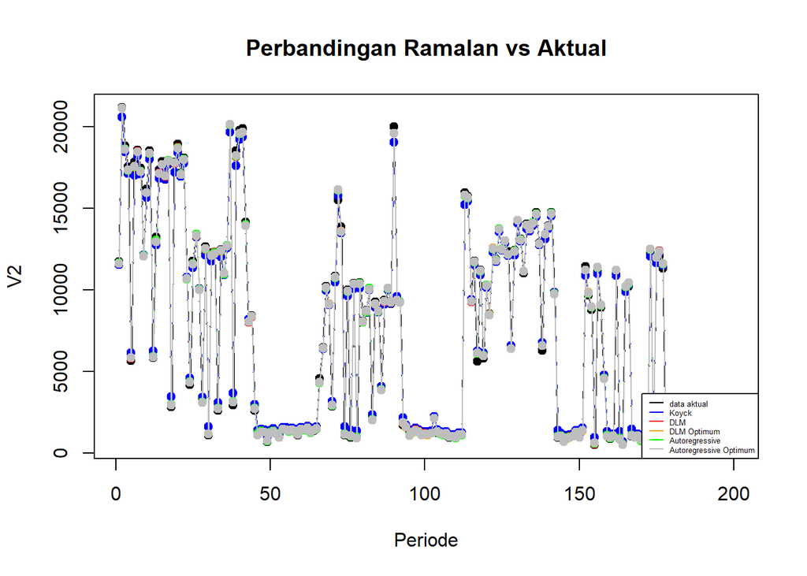

   ```r
   par(mfrow=c(1,1))
   plot(1:nrow(test), test$V2, type="b", col="black",xlab="Periode",ylab = "V2",
        main="Perbandingan Ramalan vs Aktual")
   points(1:nrow(test), test$V2,col="black",pch=19)
   lines(1:nrow(test), test$V2,col="black")
   points(1:nrow(test), fore.koyck$forecasts,col="blue",pch=19)
   lines(1:nrow(test), fore.koyck$forecasts,col="blue")
   points(1:nrow(test), fore.dlm$forecasts,col="red",pch=19)
   lines(1:nrow(test), fore.dlm$forecasts,col="red")
   points(1:nrow(test), fore.dlm2$forecasts,col="orange",pch=19)
   lines(1:nrow(test), fore.dlm2$forecasts,col="orange")
   points(1:nrow(test), fore.ardl$forecasts,col="green",pch=19)
   lines(1:nrow(test), fore.ardl$forecasts,col="green")
   points(1:nrow(test), fore.ardl2$forecasts,col="grey",pch=19)
   lines(1:nrow(test), fore.ardl2$forecasts,col="grey")
   legend("bottomright",c("data aktual", "Koyck", "DLM", "DLM Optimum", "Autoregressive", "Autoregressive Optimum"), lty=1, cex=.40,
          col=c("black", "blue", "red", "orange", "green", "grey"))
   ```